# P4_simona

2022-10-09

```r
library(ISLR)
library(MASS)
library(tidyverse)
```

1. Create a linear model object called lm_ses using the formula medv ~ lstat and the Boston dataset.

```r
#knitr::opts_chunk$set(echo = FALSE)
lm_ses <- lm(medv ~ lstat, data = Boston)
```

Use the function coef() to extract the intercept and slope from the lm_ses object. Interpret the slope coefficient.

```r
coef(lm_ses)
```

```
## (Intercept)       lstat
##  34.5538409  -0.9500494
```

3. Use summary() to get a summary of the lm_ses object. What do you see? You can use the help file ?summary.lm.

```r
summary(lm_ses)
```

```
##
## Call:
## lm(formula = medv ~ lstat, data = Boston)
##
## Residuals:
##     Min      1Q  Median      3Q     Max
## -15.168  -3.990  -1.318   2.034  24.500
##
## Coefficients:
##             Estimate Std. Error t value Pr(>|t|)
## (Intercept) 34.55384    0.56263   61.41   <2e-16 ***
## lstat       -0.95005    0.03873  -24.53   <2e-16 ***
## ---
## Signif. codes:  0 '***' 0.001 '**' 0.01 '*' 0.05 '.' 0.1 ' ' 1
##
## Residual standard error: 6.216 on 504 degrees of freedom
## Multiple R-squared:  0.5441, Adjusted R-squared:  0.5432
## F-statistic: 601.6 on 1 and 504 DF,  p-value: < 2.2e-16
```

4. Save the predicted y values to a variable called y_pred

```r
y_pred <- predict(lm_ses)
```

5. Create a scatter plot with y_pred mapped to the x position and the true y value (Boston$medv) mapped to the y value. What do you see? What would this plot look like if the fit were perfect?

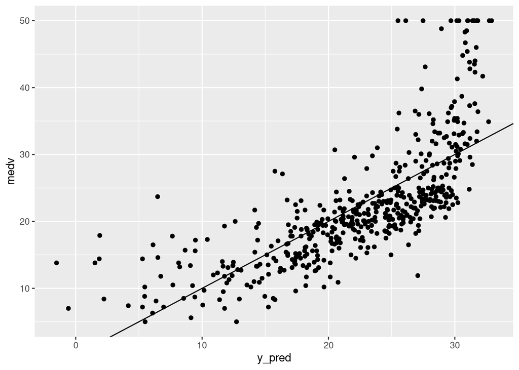

```r
Boston %>%
  ggplot( mapping = aes(x = y_pred, y = medv)) +
  geom_point() +
  geom_abline()
```

If the fit were perfect all the dots would have aligned on the line (abline)

6. Use the seq() function to generate a sequence of 1000 equally spaced values from 0 to 40. Store this vector in a data frame with (data.frame() or tibble()) as its column name lstat. Name the data frame pred_dat.

```r
pred_dat <- tibble(lstat = seq(0, 40, length.out = 1000))
```

7. Use the newly created data frame as the newdata argument to a predict() call for lm_ses. Store it in a variable named y_pred_new.

```r
y_pred_new <- predict(lm_ses, newdata = pred_dat)
```

8. Create a scatter plot from the Boston dataset with lstat mapped to the x position and medv mapped to the y position. Store the plot in an object called p_scatter.

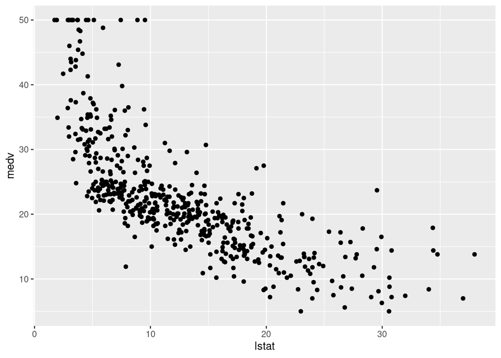

```r
p_scatter = Boston %>%
  ggplot(aes(x = lstat, y = medv)) +
  geom_point()

p_scatter
```

9.Add the vector y_pred_new to the pred_dat data frame with the name medv

```r
pred_dat <- pred_dat %>% mutate(medv = y_pred_new)
```

10. Add a geom_line() to p_scatter, with pred_dat as the data argument. What does this line represent?

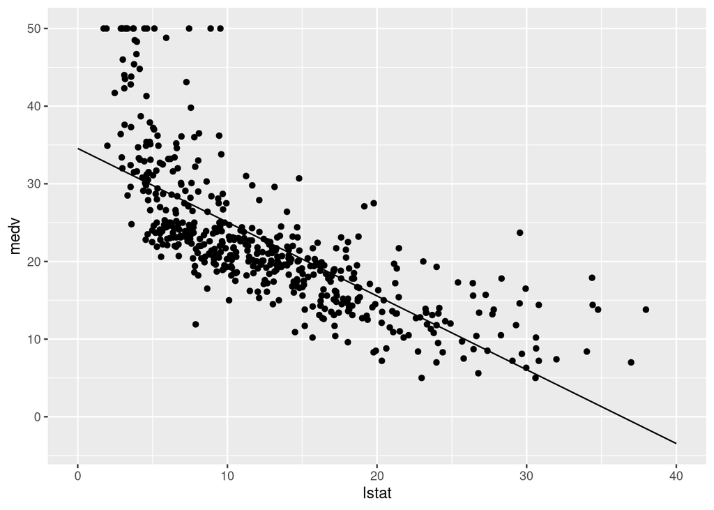

```r
p_scatter +
  geom_line(data = pred_dat)
```

11. The interval argument can be used to generate confidence or prediction intervals. 12Create a new object called y_pred_95 using predict() (again with the pred_dat data) with the interval argument set to “confidence”. What is in this object?

```r
y_pred_95 <- predict(lm_ses, newdata = pred_dat, interval = "confidence")


head(y_pred_95)
```

```
##        fit      lwr      upr
## 1 34.55384 33.44846 35.65922
## 2 34.51580 33.41307 35.61853
## 3 34.47776 33.37768 35.57784
## 4 34.43972 33.34229 35.53715
## 5 34.40168 33.30690 35.49646
## 6 34.36364 33.27150 35.45578
```

12.reate a data frame with 4 columns: medv, lstat, lower, and upper

```r
df2 <- tibble(
  lstat = pred_dat$lstat,
  medv  = y_pred_95[, 1],
  lower = y_pred_95[, 2],
  upper = y_pred_95[, 3]
)

df2
```

```
## # A tibble: 1,000 × 4
##     lstat  medv lower upper
##     <dbl> <dbl> <dbl> <dbl>
##  1 0       34.6  33.4  35.7
##  2 0.0400  34.5  33.4  35.6
##  3 0.0801  34.5  33.4  35.6
##  4 0.120   34.4  33.3  35.5
##  5 0.160   34.4  33.3  35.5
##  6 0.200   34.4  33.3  35.5
##  7 0.240   34.3  33.2  35.4
##  8 0.280   34.3  33.2  35.4
##  9 0.320   34.2  33.2  35.3
## 10 0.360   34.2  33.1  35.3
## # … with 990 more rows
```

13. Add a geom_ribbon() to the plot with the data frame you just made. The ribbon geom requires three aesthetics: x (lstat, already mapped), ymin (lower), and ymax (upper). Add the ribbon below the geom_line() and the geom_points() of before to make sure those remain visible. Give it a nice colour and clean up the plot, too!

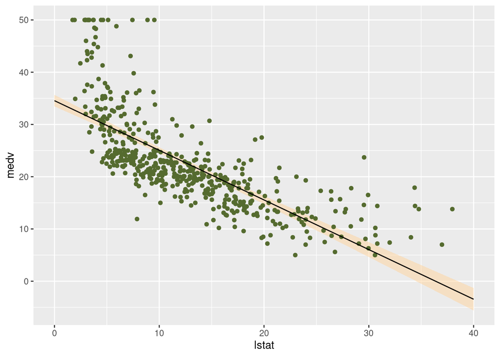

```r
Boston %>%
  ggplot(aes(x = lstat, y = medv)) +
  geom_ribbon(aes(ymin = lower, ymax = upper), data = df2, fill = "burlywood1", alpha = 0.5) +
  geom_point(colour = "darkolivegreen") +
  geom_line(data = pred_dat)
```

14. Explain in your own words what the ribbon represents.

```r
#The ribbon represents the 95% confidence interval of the predicted values of medv. It takes into the account the variablity of the estimates.
```

15. Do the same thing, but now with the prediction interval instead of the confidence interval.

```r
y_pred_95 <- predict(lm_ses, newdata = pred_dat, interval = "prediction")

df2 <- tibble(
  lstat = pred_dat$lstat,
  medv  = y_pred_95[, 1],
  lower = y_pred_95[, 2],
  upper = y_pred_95[, 3]
)

df2
```

```
## # A tibble: 1,000 × 4
##     lstat  medv lower upper
##     <dbl> <dbl> <dbl> <dbl>
##  1 0       34.6  22.3  46.8
##  2 0.0400  34.5  22.3  46.8
##  3 0.0801  34.5  22.2  46.7
##  4 0.120   34.4  22.2  46.7
##  5 0.160   34.4  22.1  46.7
##  6 0.200   34.4  22.1  46.6
##  7 0.240   34.3  22.1  46.6
##  8 0.280   34.3  22.0  46.5
##  9 0.320   34.2  22.0  46.5
## 10 0.360   34.2  22.0  46.5
## # … with 990 more rows
```

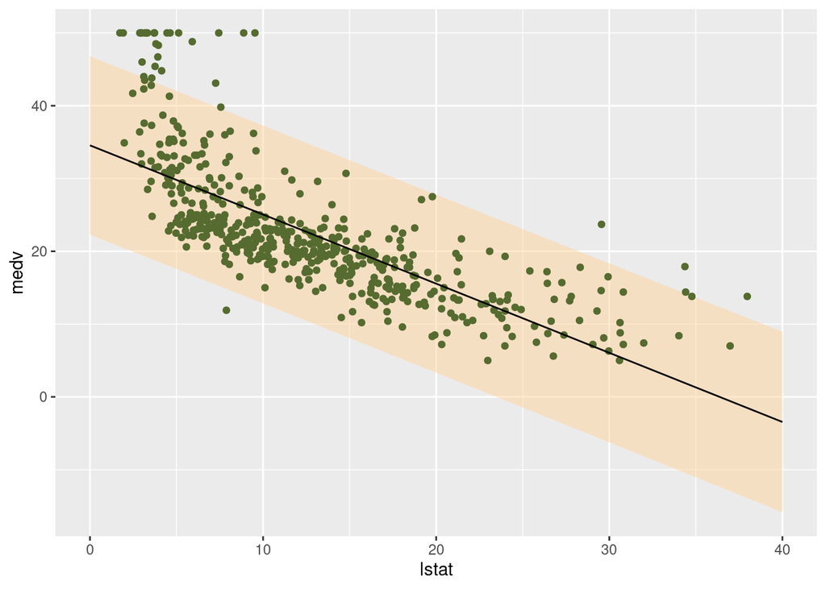

```r
Boston %>%
  ggplot(aes(x = lstat, y = medv)) +
  geom_ribbon(aes(ymin = lower, ymax = upper), data = df2, fill = "burlywood1", alpha = 0.5) +
  geom_point(colour = "darkolivegreen") +
  geom_line(data = pred_dat)
```

16. Write a function called mse() that takes in two vectors: true y values and predicted y values, and which outputs the mean square error.

```r
mse <- function(y_true, y_pred) {
  mean((y_true - y_pred)^2)
}
```

```r
mse(1:10, 10:1)
```

```
## [1] 33
```

19. Calculate the mean square error of the lm_ses model. Use the medv column as y_true and use the predict() method to generate y_pred

```r
y_pred <- predict(lm_ses)
mse(Boston$medv, y_pred )
```

```
## [1] 38.48297
```

19. The Boston dataset has 506 observations. Use c() and rep() to create a #vector with 253 times the word “train”, 152 times the word “validation”, #and 101 times the word “test”. Call this vector splits.

```r
splits <- rep(c("train", "validation", "test"), times = c(253, 152, 101))
head(splits)
```

```
## [1] "train" "train" "train" "train" "train" "train"
```

20. Use the function sample() to randomly order this vector and add it to the Boston dataset using mutate(). Assign the newly created dataset to a variable called boston_master.

```r
splits <- sample(splits, size = 506)

boston_master <- Boston %>% mutate( splits = splits)
```

21. Now use filter() to create a training, validation, and test set from the boston_master data. Call these datasets boston_train, boston_valid, and boston_test.

```r
boston_train <- boston_master %>% filter(splits == "train")
boston_valid <- boston_master %>% filter(splits == "validation")
boston_test  <- boston_master %>% filter(splits == "test")
```

22. Train a linear regression model called model_1 using the training dataset. #Use the formula medv ~ lstat like in the first lm() exercise. #Use summary() to check that this object is as you expect.

```r
model_1 <- lm(medv ~ lstat   , data = boston_train)
summary(model_1)
```

```
##
## Call:
## lm(formula = medv ~ lstat, data = boston_train)
##
## Residuals:
##     Min      1Q  Median      3Q     Max
## -10.797  -4.852  -1.462   2.835  23.600
##
## Coefficients:
##             Estimate Std. Error t value Pr(>|t|)
## (Intercept) 36.30996    0.84366   43.04   <2e-16 ***
## lstat       -1.03988    0.05921  -17.56   <2e-16 ***
## ---
## Signif. codes:  0 '***' 0.001 '**' 0.01 '*' 0.05 '.' 0.1 ' ' 1
##
## Residual standard error: 6.843 on 251 degrees of freedom
## Multiple R-squared:  0.5513, Adjusted R-squared:  0.5496
## F-statistic: 308.4 on 1 and 251 DF,  p-value: < 2.2e-16
```

#23. calculate the MSE with this object. Save this value as model_1_mse_train

```r
model_1_mse <- mse(boston_train$medv, predict(model_1))
```

24. Now calculate the MSE on the validation set and assign it #to variable model_1_mse_valid. Hint: use the newdata argument in predict().

```r
model_1_mse_valid <- mse(boston_valid$medv, predict(model_1, newdata = boston_valid))
```

25. Create a second model model_2 for the train data which includes age and tax as predictors. #Calculate the train and validation MSE.

```r
model2 <- lm(medv ~ age + tax, data = boston_train)

model2_train_mse <- mse(boston_train$medv, predict(model2))

model2_validation <- mse(boston_valid$medv, predict(model2, newdata = boston_valid))
```

26. Compare model 1 and model 2 in terms of their training and validation MSE. #Which would you choose and why?

```r
summary(model2)
```

```
##
## Call:
## lm(formula = medv ~ age + tax, data = boston_train)
##
## Residuals:
##     Min      1Q  Median      3Q     Max
## -11.881  -5.659  -2.940   3.096  33.260
##
## Coefficients:
##              Estimate Std. Error t value Pr(>|t|)
## (Intercept) 36.066067   1.755897  20.540  < 2e-16 ***
## age         -0.064926   0.024159  -2.687  0.00768 **
## tax         -0.019270   0.003895  -4.947 1.38e-06 ***
## ---
## Signif. codes:  0 '***' 0.001 '**' 0.01 '*' 0.05 '.' 0.1 ' ' 1
##
## Residual standard error: 9.2 on 250 degrees of freedom
## Multiple R-squared:  0.1924, Adjusted R-squared:  0.1859
## F-statistic: 29.77 on 2 and 250 DF,  p-value: 2.528e-12
```

```r
summary(model_1)
```

```
##
## Call:
## lm(formula = medv ~ lstat, data = boston_train)
##
## Residuals:
##     Min      1Q  Median      3Q     Max
## -10.797  -4.852  -1.462   2.835  23.600
##
## Coefficients:
##             Estimate Std. Error t value Pr(>|t|)
## (Intercept) 36.30996    0.84366   43.04   <2e-16 ***
## lstat       -1.03988    0.05921  -17.56   <2e-16 ***
## ---
## Signif. codes:  0 '***' 0.001 '**' 0.01 '*' 0.05 '.' 0.1 ' ' 1
##
## Residual standard error: 6.843 on 251 degrees of freedom
## Multiple R-squared:  0.5513, Adjusted R-squared:  0.5496
## F-statistic: 308.4 on 1 and 251 DF,  p-value: < 2.2e-16
```

```r
model_1_mse
```

```
## [1] 46.45813
```

```r
model_1_mse_valid
```

```
## [1] 33.85149
```

```r
model2_train_mse
```

```
## [1] 83.63097
```

```r
model2_validation
```

```
## [1] 43.82929
```

27. Calculate the test MSE for the model of your choice in the previous question. What does this number tell you?

```r
model2_test_mse <- mse(boston_test$medv, predict(model2, newdata = boston_test))
model2_test_mse
```

```
## [1] 51.05972
```

The mse went down. While this is good it varies a lot from the previous mses.

```r
sqrt(model2_test_mse)
```

```
## [1] 7.145608
```

28. create a function that performs k-fold cross-validation for linear models.

```r
k_valid <- function(formula, dataset, k){
#Shuffle the data
  dataset= dataset[sample(1:nrow(dataset)), ]
  #First I will construct a vector for partition of the data and append it to the dataframe
  number_in_slice <- floor(nrow(dataset)/k)
  splits_vector <- rep(c(1:k), times = number_in_slice)
  difference <- nrow(dataset) - length(splits_vector)
  print(difference)
  splits_vector = append(splits_vector, rep(1, difference ))

  dataset["partition"]  = splits_vector


#I will select the groups to be the test dataset
  vector_mse = c()
  for (i in 1:k)
  {
    test_data <- dataset %>% filter(partition != i)

    valid_data <- dataset %>%  filter(partition == i)

    #fitting a model on the training set
    model_train <- lm(formula, data = test_data)

    #get the mse
    y_column_name <- as.character(formula)[2]
    vector_mse[i] <- mse(valid_data[, y_column_name], predict(model_train, newdata = valid_data ))
  }

  mean(vector_mse)

# The End...
}
```

```r
k_valid(formula = medv ~ lstat + age + tax, dataset = Boston, k = 9)
```

```
## [1] 2
```

```
## [1] 37.90122
```